# Myco phosphoproteomics data normalisation

Marie Locard-Paulet

Wed Mar 28 09:59:47 2018

This study is the analysis of the three following *Mycobacterium smegmatis* samples:

- **L**: wild type transfected with the empty vector.
- **P**: with over-expressed PknB.
- **K**: with over-expressed mutated PknB-K40M (inactive).

Alex and Hung prepared 1 mg of digested peptides (in solution digestion) and subjected 500ug to TiO2 enrichment. The samples prior and after phospho-enrichment were injected onto the Q-Exactive Plus in technical duplicate. We work with 3 biological replicates (independent transfections).

# Proteome

## Data set inspection

The raw files of the proteomic data set are in `RAW/Proteome_MQ041217/`. We work with the Max Quant table `proteinGroups.txt`.

I remove the “REV_” and “CON_”, and I keep only the proteins identified/quantified with a minimum of 2 unique peptides.

**There are 3583 proteins identified in the study.**

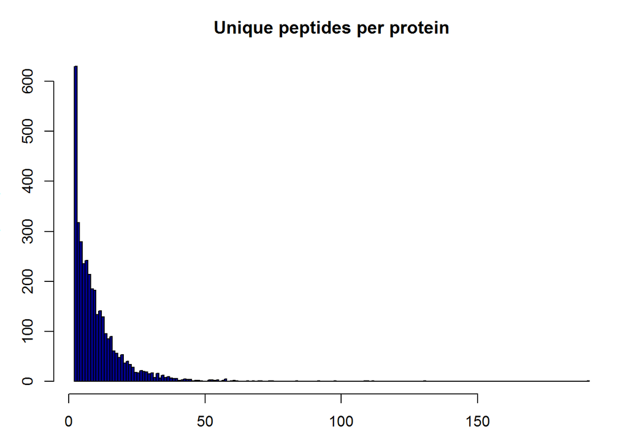

## Retrieve the gene names in Uniprot to correct the trimmed “Fasta header” values

I export the protein IDs for manual retrieving using `https://www.uniprot.org/uploadlists/` (20180117).

We searched the data with 2 proteome annotations from Uniprot (see document `ProteomesComparison`). I choose a unique ID to be able to match the proteomic to the phospho-proteomic data later on.

The new column “Proteome” contains the information of from which proteome comes the ID. The “FALSE” are the “Pknbtub” sequences that we added and a “Biognosys7”.

| Var1 | Freq |
| --- | --- |
| FALSE | 2 |
| UP000000757: Chromosome | 40 |
| UP000000757: Chromosome; UP000000757: Chromosome; UP000006158: Chromosome; UP000006158: Chromosome | 3 |
| UP000000757: Chromosome; UP000006158: Chromosome | 3488 |
| UP000006158: Chromosome | 50 |

To simplify the table, I keep only one gene name if possible. I decide to first keep the gene name. If this is not available, I keep the“MSMEG” ID, if there is none I keep the “MSMEI”.

I manually check that there is no ID ambiguity in the protein names attribution.

## Normalisation

I use the LFQ values for the quantification.

In the following boxplot:

- the red points are the quan values for PknB of smegmatis.
- the blue points are the quan values for PknB of tub.
- the green points are the quan values for mutant PknB of tub.

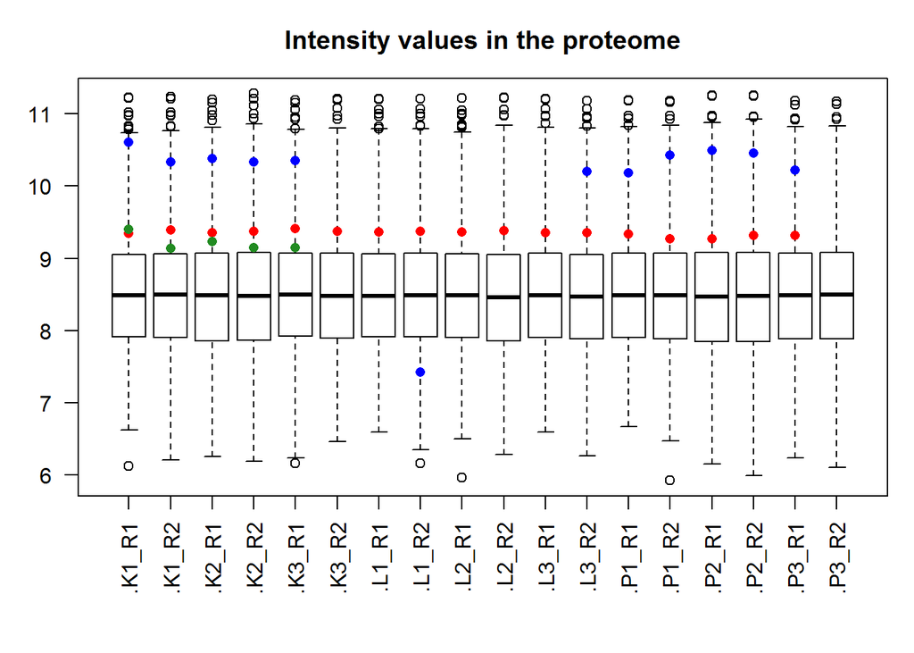

## Plot PknB quan values

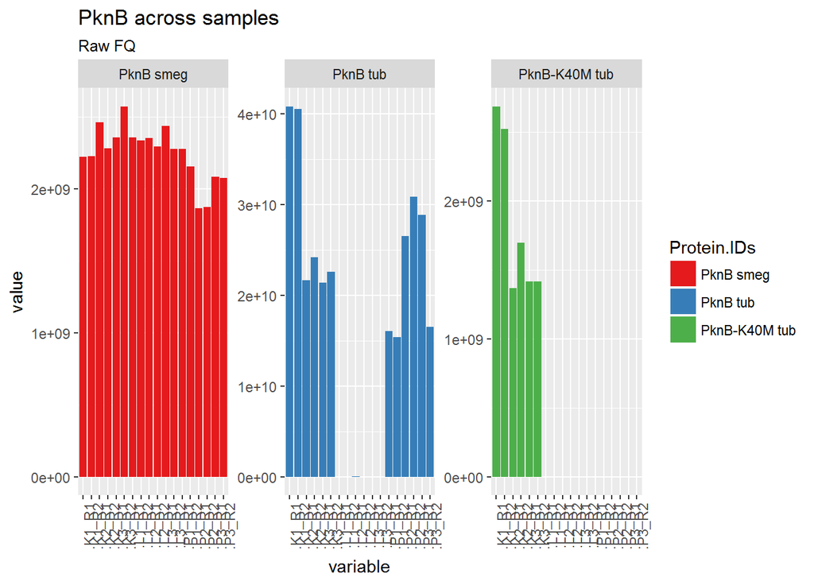

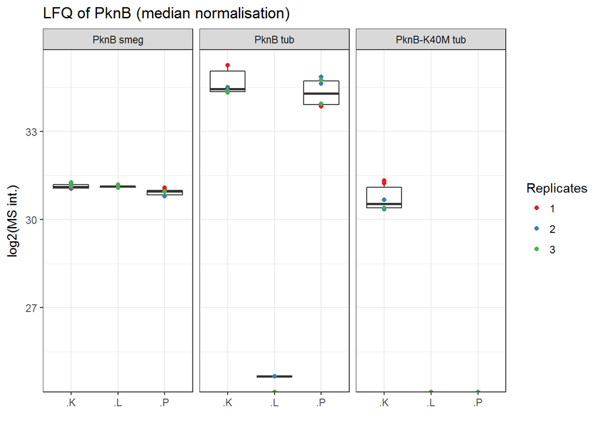

## Multivariate analysis

Reproducibility of the MS runs:

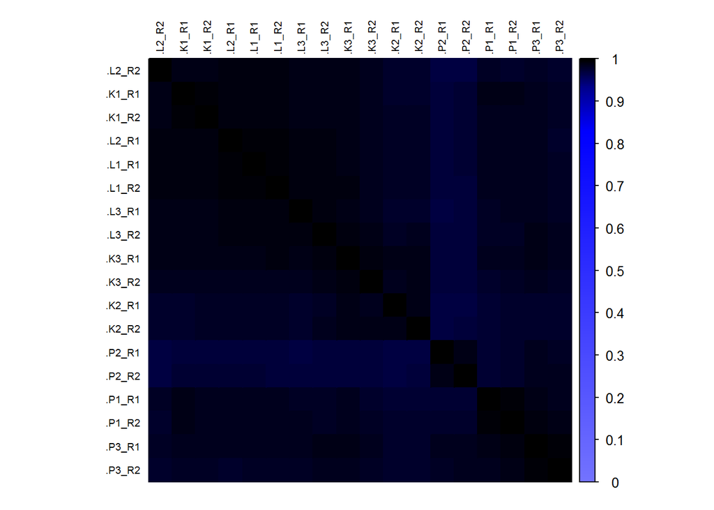

I save the protein table as `OutputTables/NormIntProt_20180109.txt`.

## Statistical analysis

Calculate the mean of the technical repeats:

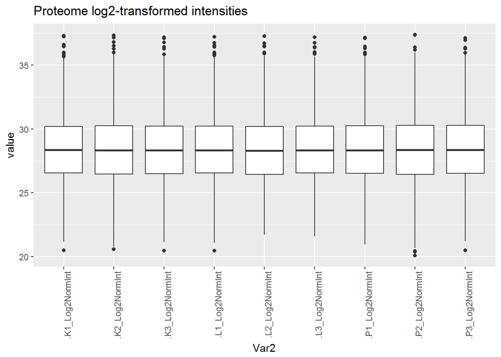

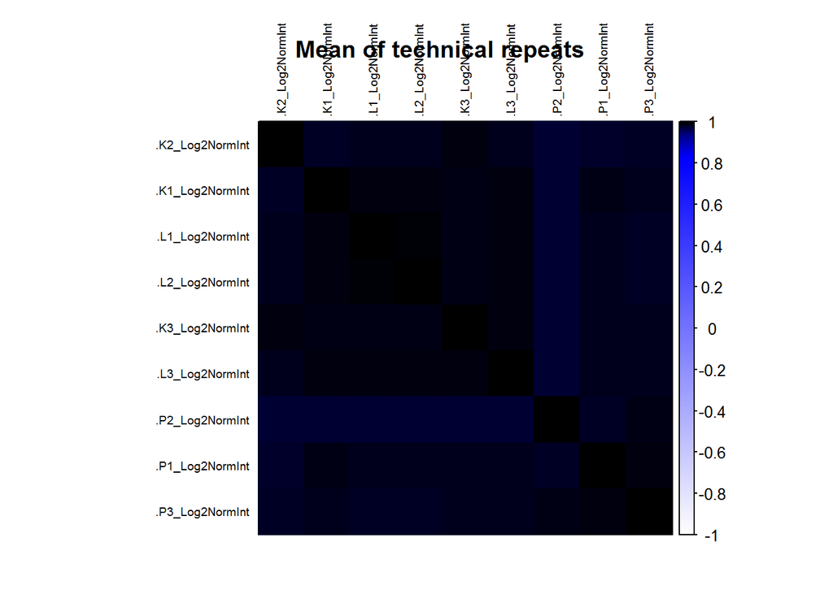

## Figure PknB levels in the different samples

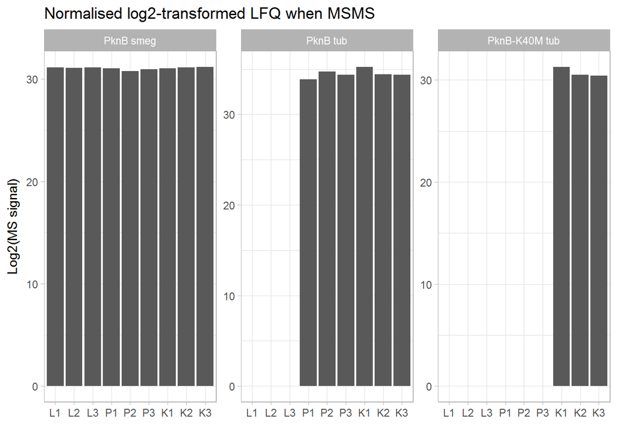

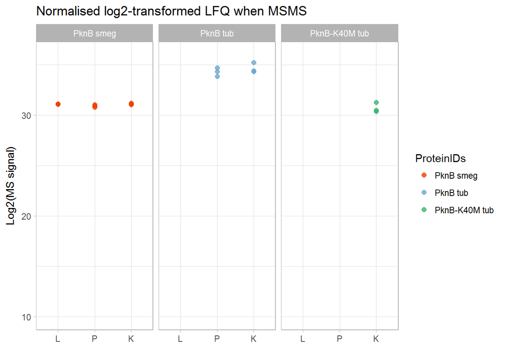

## Replacement of missing values

I replace with 1% quantile from each condition

I replace missing values when there is one or no value detected across the 3 experiments in one condition (conditions being L, K, P).

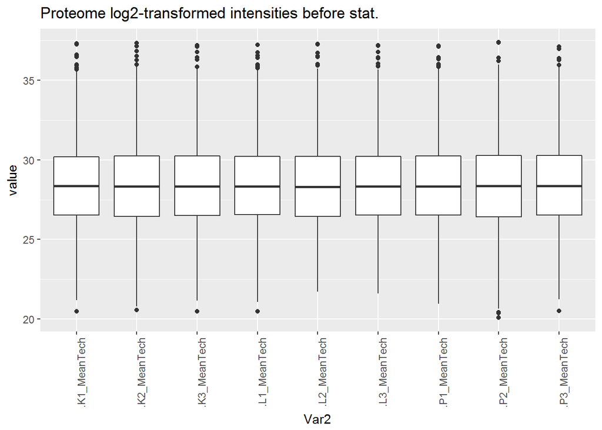

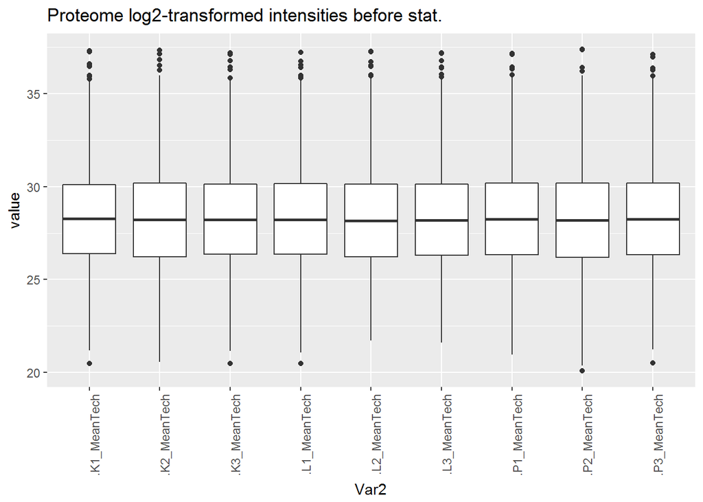

I perform a Welch two-sided t-test followed by a BH correction of the pvalue:

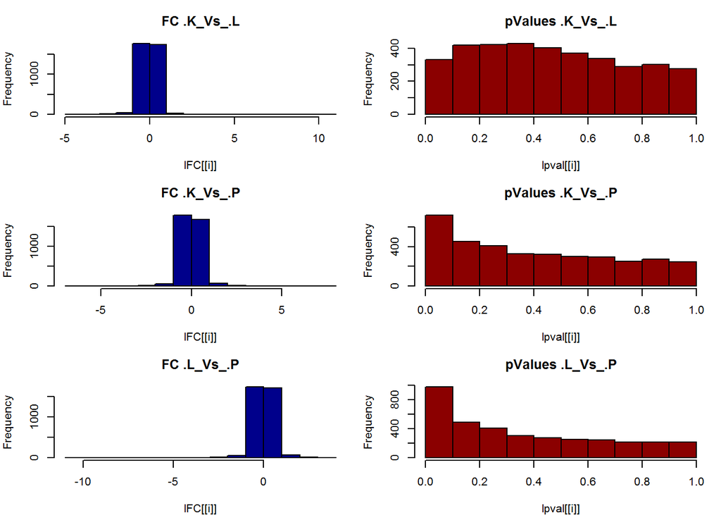

## Volcano plots

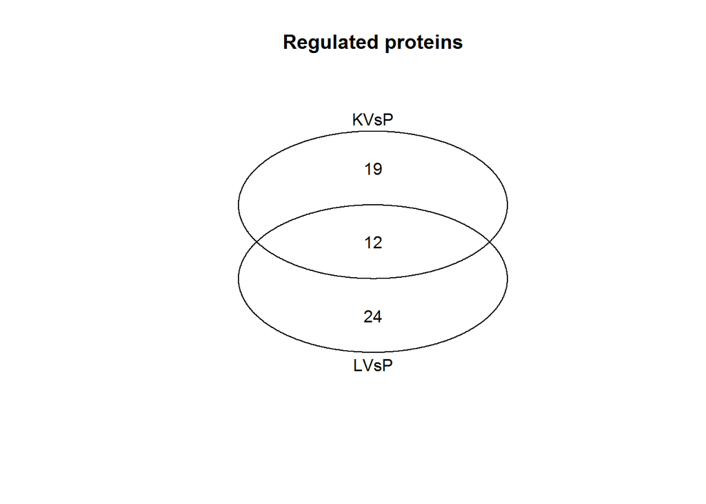

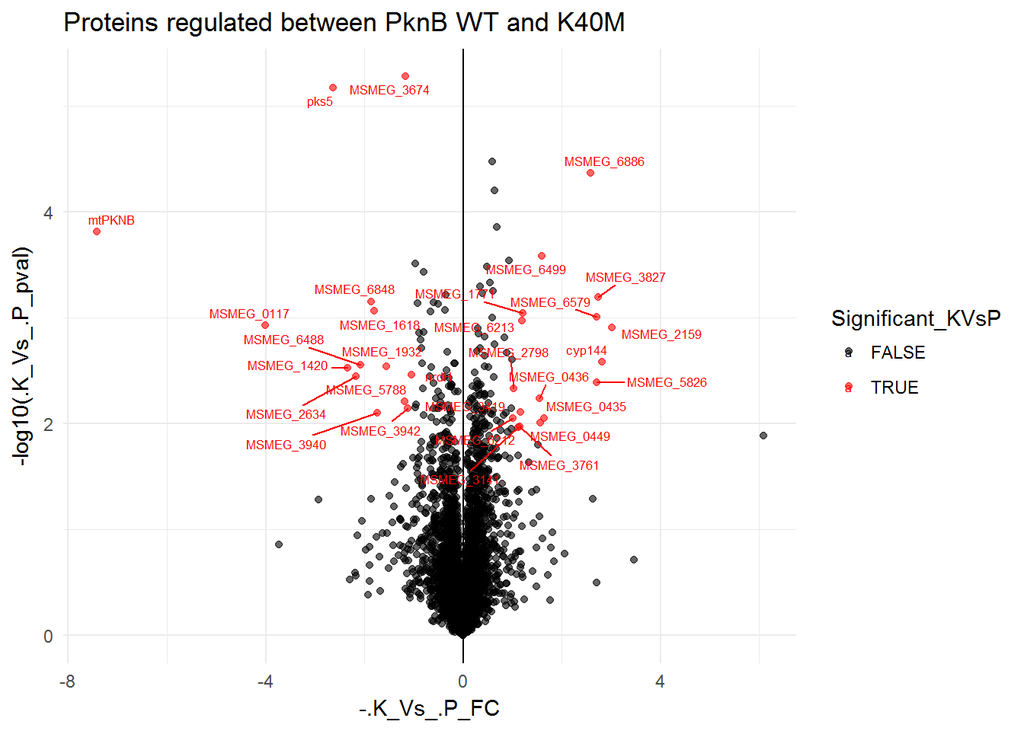

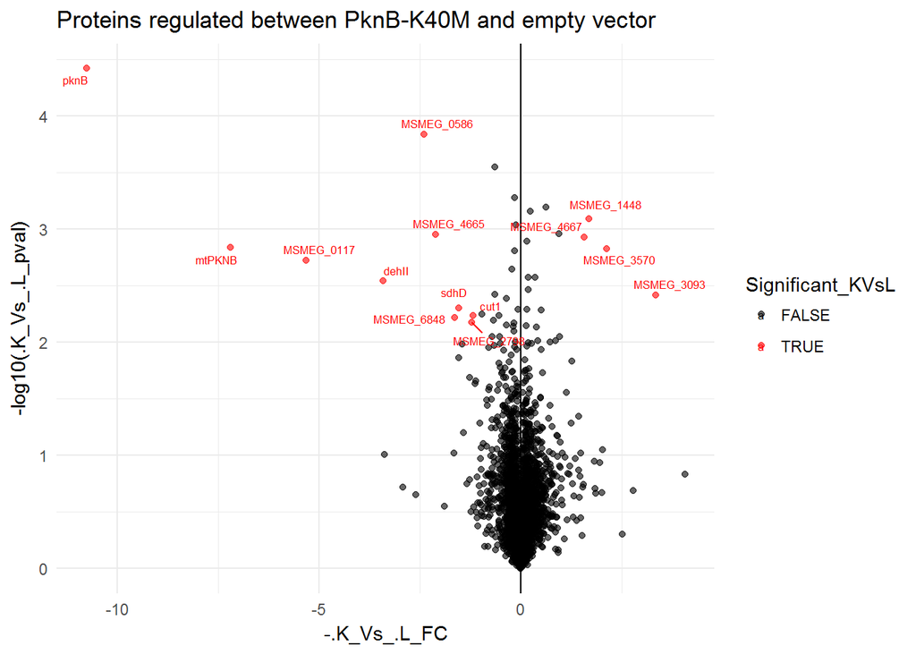

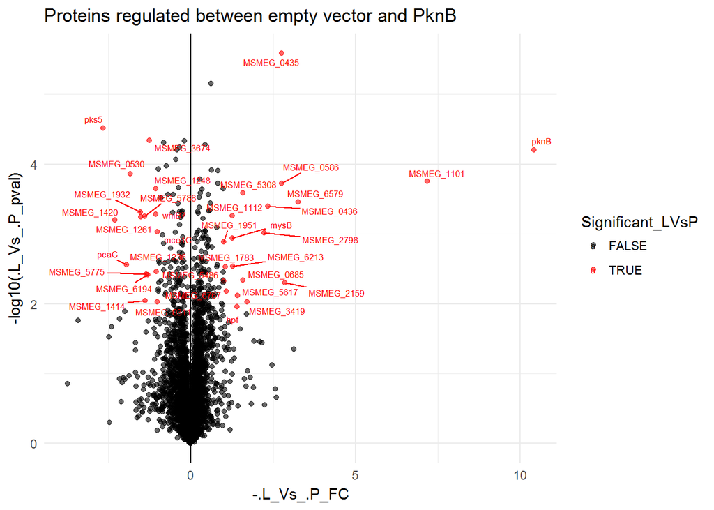

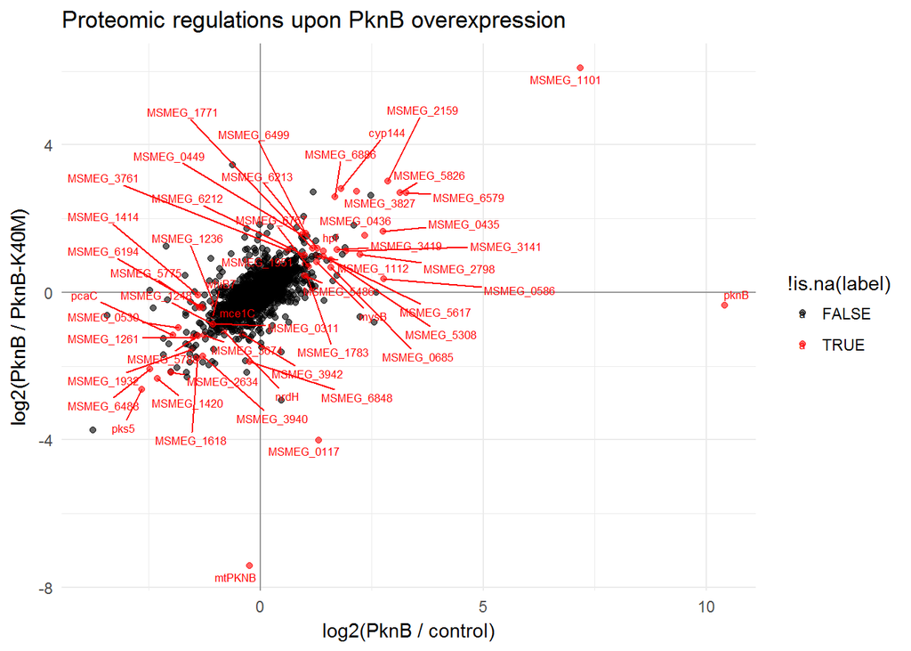

## Normalisation factor for phosphoproteomics data set

I calculate a normalisation factor for each protein in each run. The vertical red line indicate the median intensity of PknB.

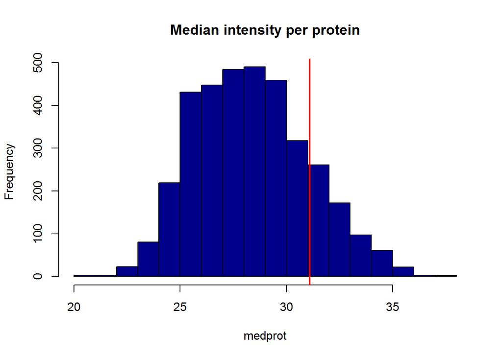

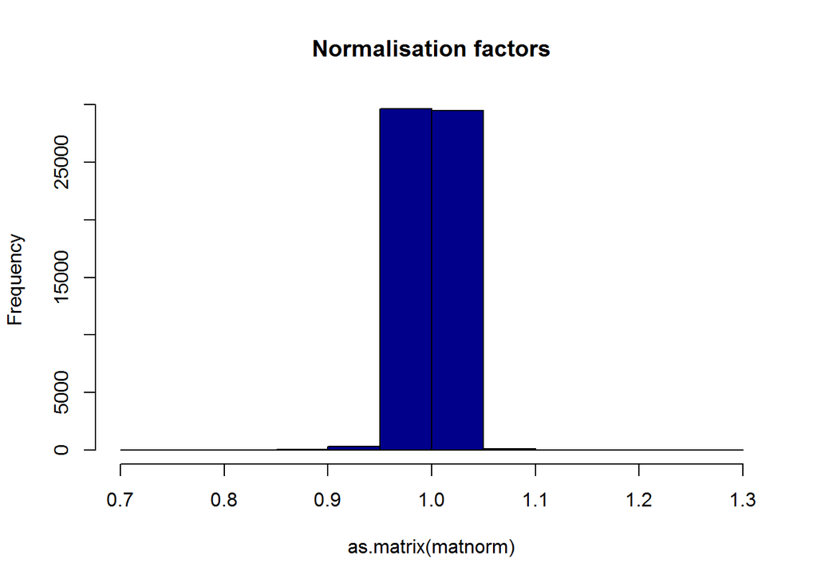

# Phospho-enriched samples

## Quality check

I remove the `CON_` and `REV_`.

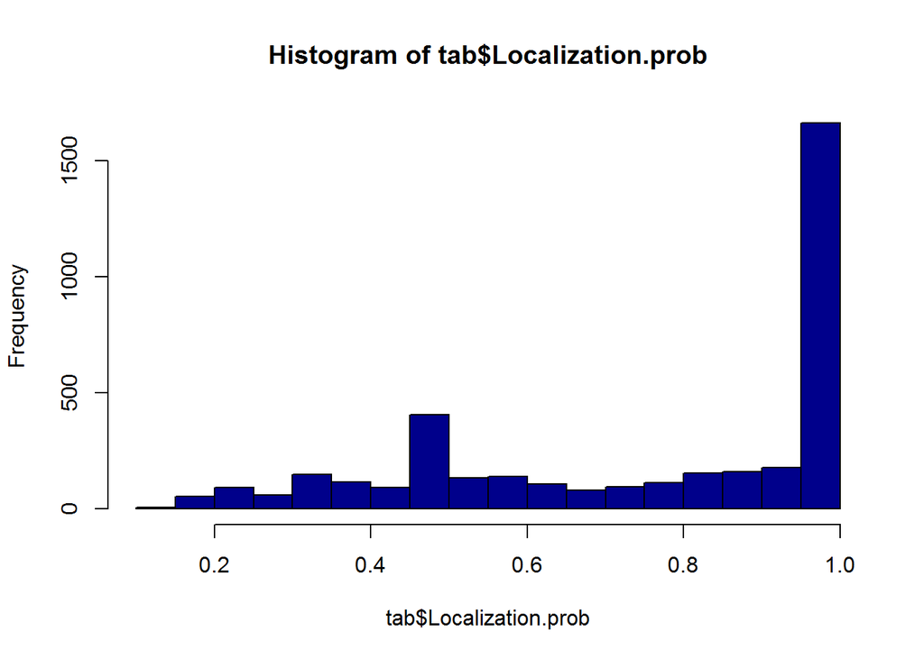

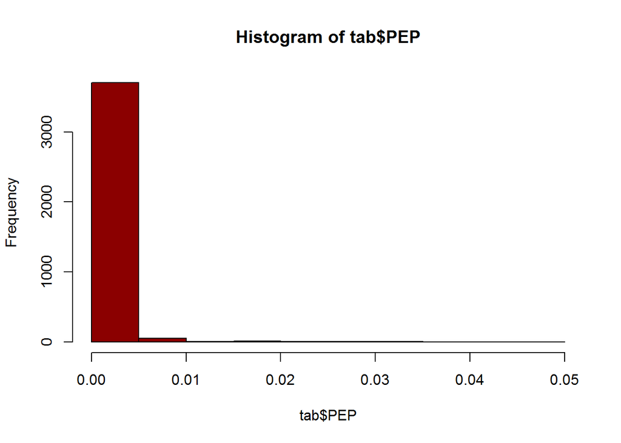

There are 3798 phosphorylation sites identified in the study (from 1339 proteins).

I keep only the sites with 75% localisation probability (above or equal):

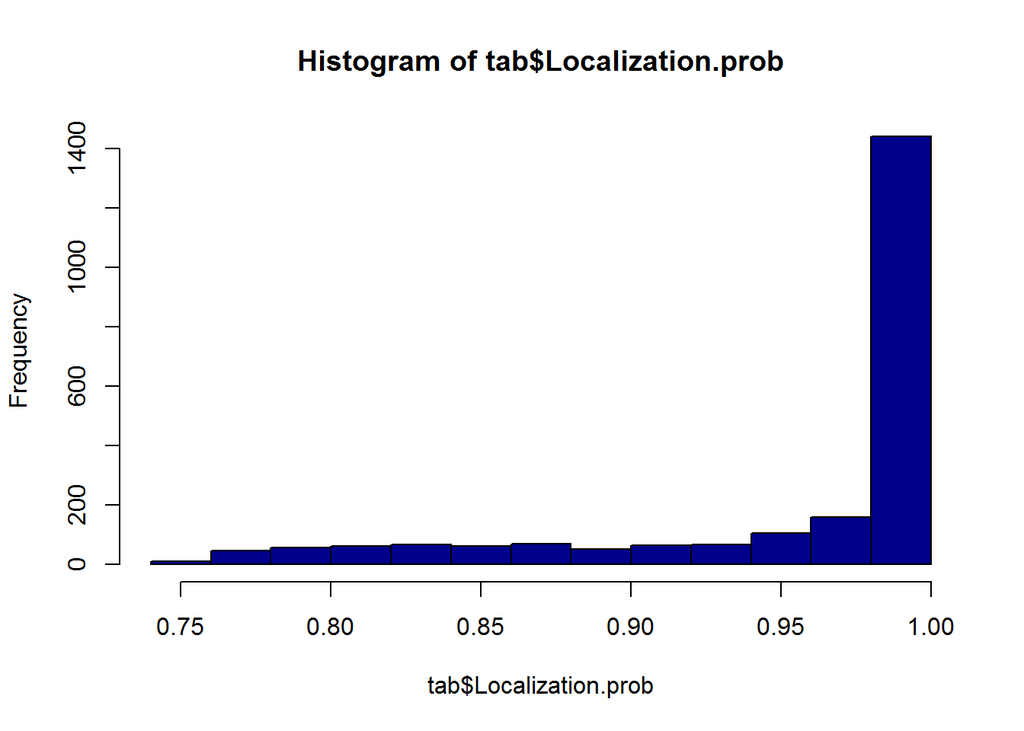

There are 2256 phosphorylation sites identified in the study (from 1175 proteins).

## Retrieve the gene names in Uniprot to correct the trimmed “Fasta header” values

I export the protein IDs for manual retrieving using `https://www.uniprot.org/uploadlists/` (20180117).

We searched the data with 2 proteome annotations from Uniprot (see document `ProteomesComparison`). I choose a unique ID to be able to match the proteomic to the phospho-proteomic data later on.

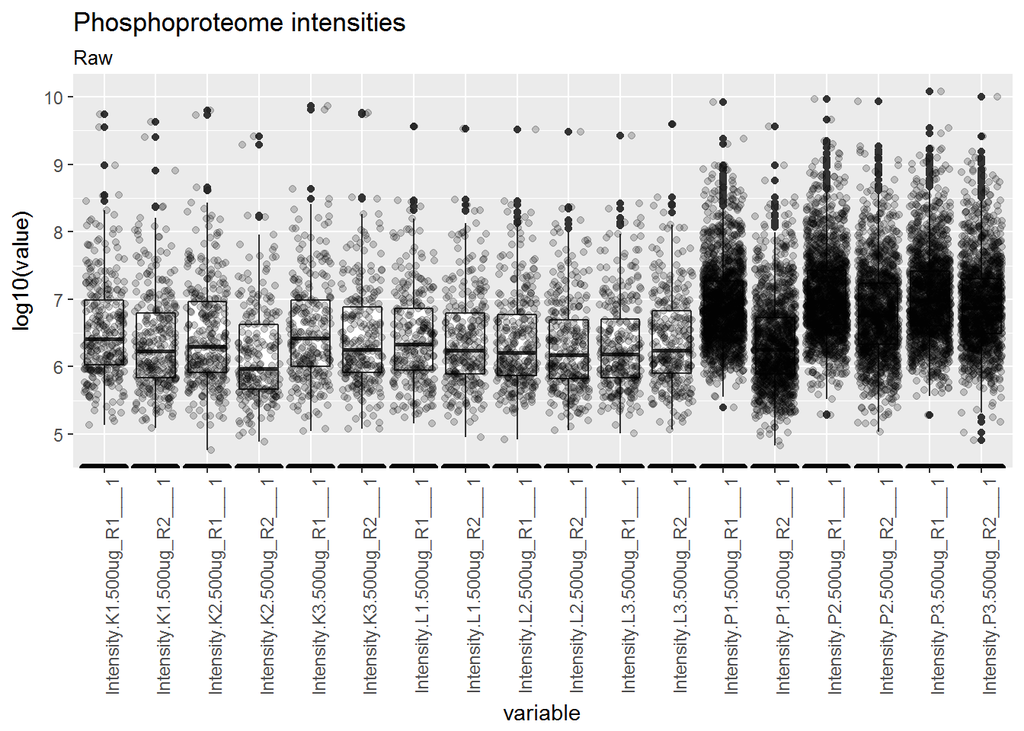

## Normalisation based on the iRTs

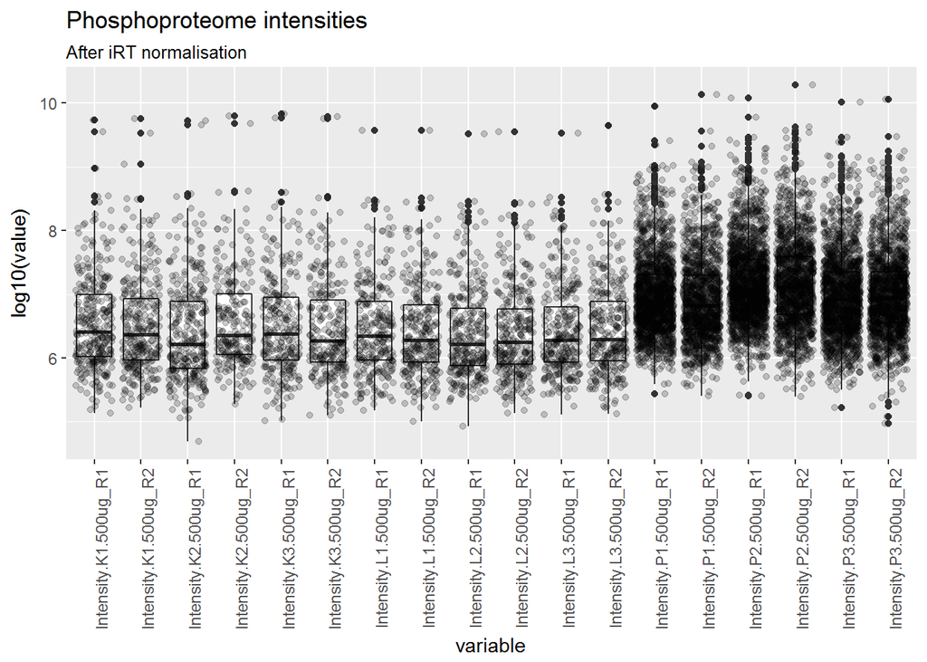

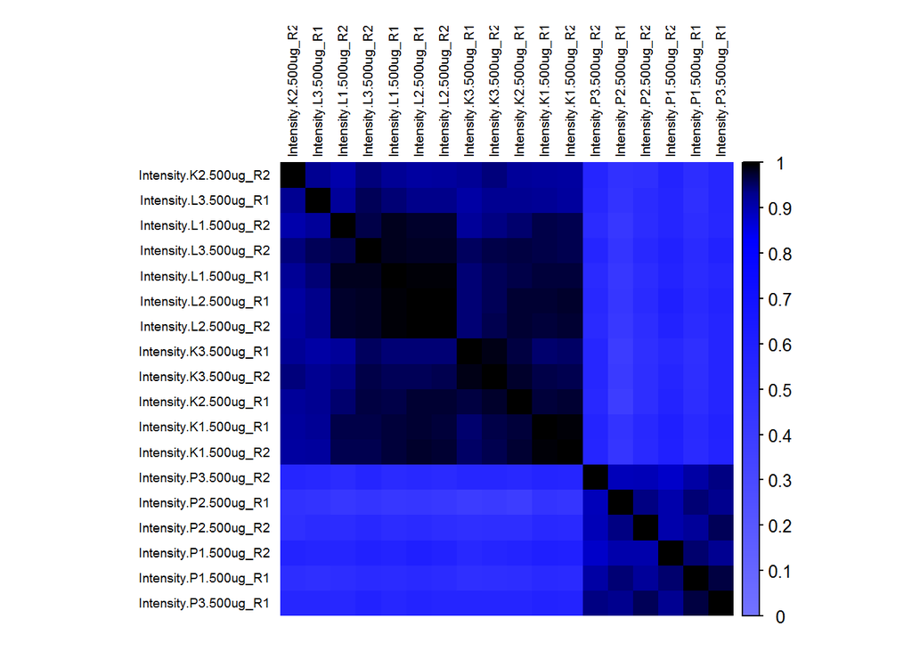

## Normalisation to the protein changes

Each protein is normalised with a normalisation factor calculated in the proteomics data set.

I remove the CON_ and REV_ in the phospho table.

**There are 2256 rows in the phospho table.**

I finely match the protein ID from the phospho data set to the proteome.

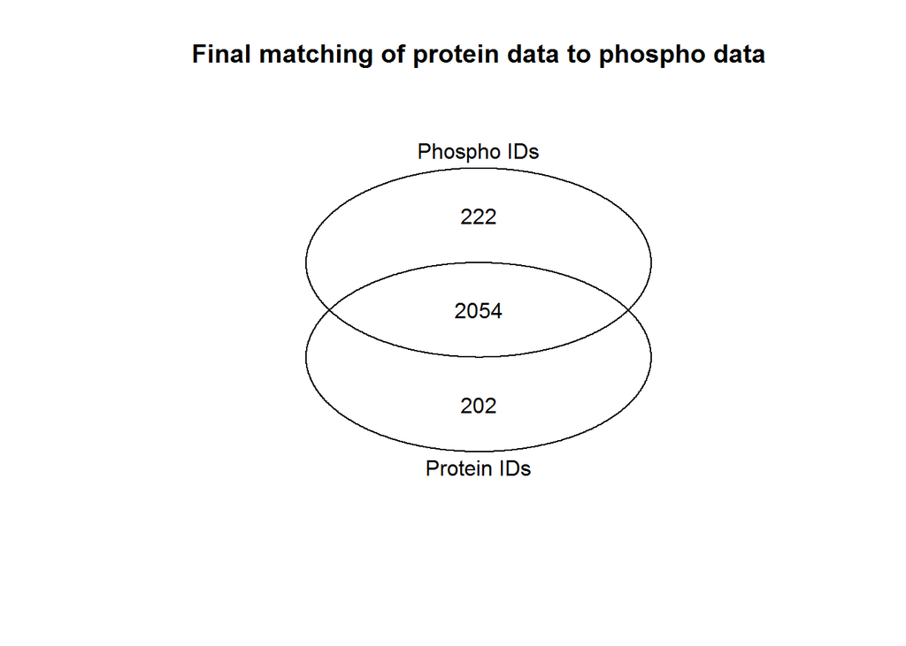

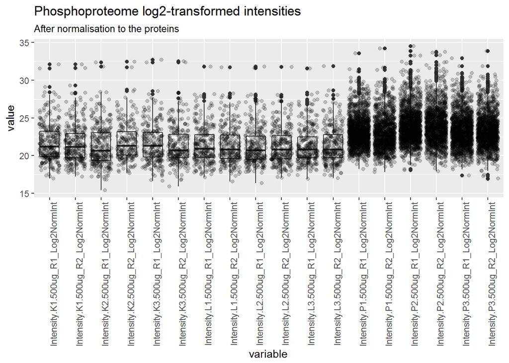

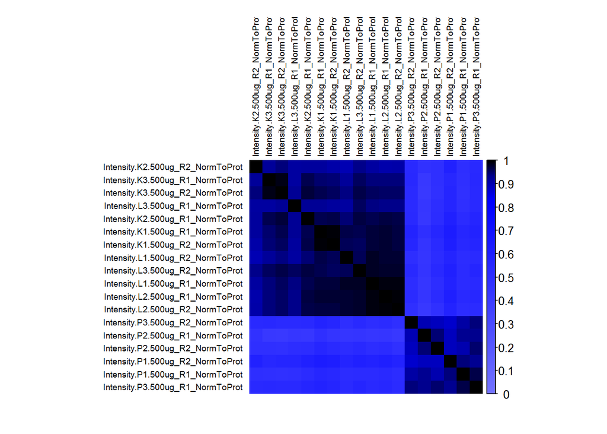

# Calculation of the values per biological repeat

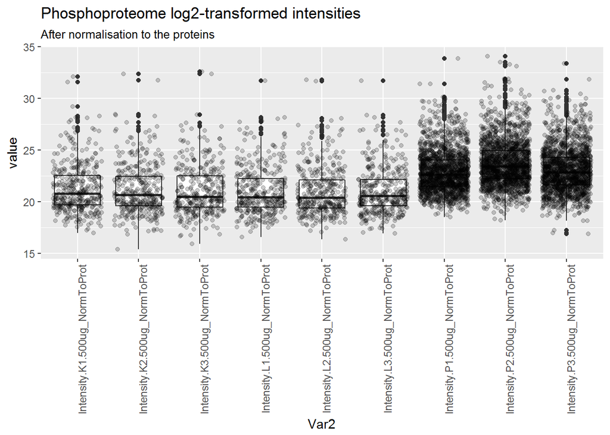

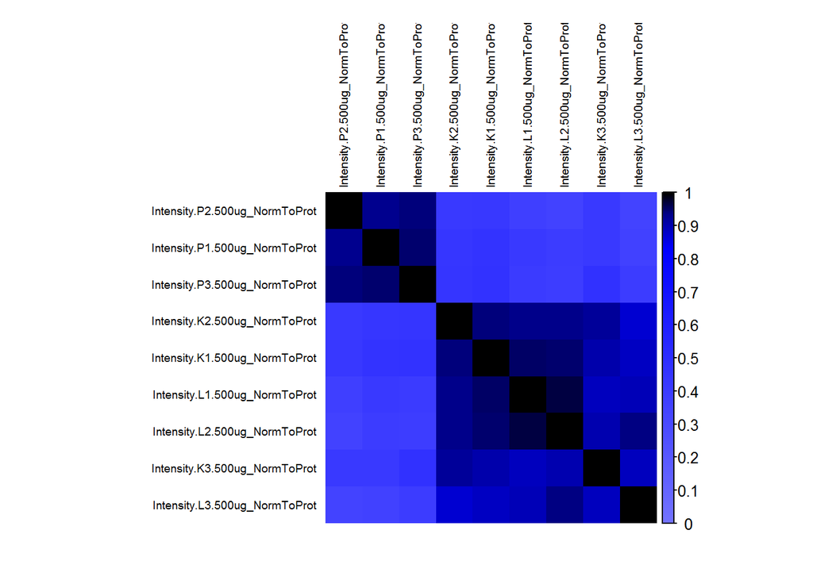

```
## Importance of components:
##                          PC1    PC2     PC3     PC4     PC5     PC6
## Standard deviation     6.210 3.4677 0.99835 0.90905 0.63414 0.56883
## Proportion of Variance 0.718 0.2239 0.01856 0.01538 0.00749 0.00602
## Cumulative Proportion  0.718 0.9418 0.96038 0.97576 0.98325 0.98928
##                            PC7     PC8     PC9
## Standard deviation     0.52697 0.42904 0.33809
## Proportion of Variance 0.00517 0.00343 0.00213
## Cumulative Proportion  0.99444 0.99787 1.00000
```

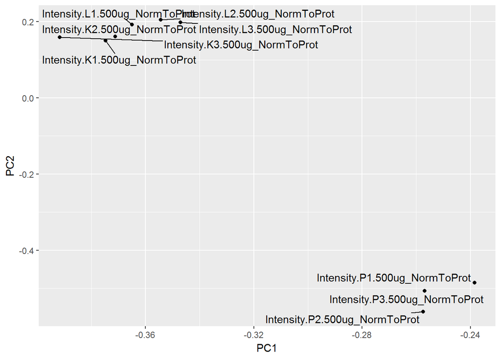

I add the information in the output table.